# GRH Forecast Evaluation

All flow conditions

Report created: 2026-09-16 15:38:30.586922

## Metric Descriptions

- *NSE* - Nash-Sutcliffe Efficiency, a metric that measures performance relative to the mean of the data, values range from [-∞ , 1], with values greater than 0 indicating better performance than the mean, and a perfect forecast will have a value of 1.
- *KGE* - Kling-Gupta Efficiency, a metric that is often used similarly to NSE, but addresses several shortcomings by explicitly incorporating variability and correlation between simulations and observations. Values can range from [-∞ , 1] with negative values generally considered to indicate poor performance.
- *PBIAS* - Percent Bias, Bias of the simulation relative to the observations, represented as a percent. Negative values indicate a low bias and positive values indicate a high bias, values closer to 0 are preferable.
- *nRMSE* - Normalized root mean square error, expressed as a percent, lower values are better.
- *r* - Pearson’s correlation, a measure of how well the forecast and observations are correlated, values closer to 1 indicate better correlation.
- *rSD* - Ratio of standard deviations of forecast and observed. Values close to 1 are preferable as they indicate that the forecast has the same variability as the observations.

### Day Ahead Forecast Statistics

#### Overall

| source | location | NSE | KGE | PBIAS | nRMSE | r | rSD |
| --- | --- | --- | --- | --- | --- | --- | --- |
| A | wilder | 0.725 | 0.834 | -8.0 | 52.4 | 0.884 | 1.087 |
| B | wilder | 0.832 | 0.876 | 0.1 | 40.9 | 0.929 | 1.102 |
| GRH | wilder | 0.882 | 0.885 | -9.9 | 34.4 | 0.951 | 0.970 |
| perfect | wilder | 1.000 | 1.000 | 0.0 | 0.0 | 1.000 | 1.000 |
| persistence | wilder | -0.811 | 0.016 | -75.9 | 134.5 | 0.750 | 0.426 |
| A | bellows | 0.545 | 0.773 | 0.4 | 67.4 | 0.773 | 1.002 |
| B | bellows | 0.911 | 0.951 | 0.6 | 29.8 | 0.955 | 0.982 |
| GRH | bellows | 0.850 | 0.877 | -10.4 | 38.7 | 0.933 | 0.995 |
| perfect | bellows | 1.000 | 1.000 | 0.0 | 0.0 | 1.000 | 1.000 |
| persistence | bellows | 0.394 | 0.349 | -39.2 | 77.8 | 0.870 | 0.496 |
| A | vernon | 0.806 | 0.835 | -11.3 | 44.1 | 0.907 | 0.924 |
| B | vernon | 0.888 | 0.940 | 1.7 | 33.4 | 0.944 | 0.990 |
| GRH | vernon | 0.888 | 0.876 | -11.0 | 33.5 | 0.951 | 0.970 |
| perfect | vernon | 1.000 | 1.000 | 0.0 | 0.0 | 1.000 | 1.000 |
| persistence | vernon | 0.801 | 0.691 | -18.1 | 44.6 | 0.934 | 0.758 |

#### Winter

| source | location | season | NSE | KGE | PBIAS | nRMSE | r | rSD |
| --- | --- | --- | --- | --- | --- | --- | --- | --- |
| A | wilder | winter | 0.628 | 0.812 | -0.3 | 60.7 | 0.832 | 1.083 |
| B | wilder | winter | 0.746 | 0.738 | -1.4 | 50.2 | 0.924 | 1.250 |
| GRH | wilder | winter | 0.876 | 0.852 | -11.6 | 34.9 | 0.958 | 0.919 |
| perfect | wilder | winter | 1.000 | 1.000 | 0.0 | 0.0 | 1.000 | 1.000 |
| persistence | wilder | winter | -0.749 | 0.025 | -74.5 | 131.9 | 0.839 | 0.392 |
| A | bellows | winter | -0.088 | 0.450 | 31.9 | 103.7 | 0.553 | 0.963 |
| B | bellows | winter | 0.915 | 0.922 | -0.3 | 29.1 | 0.962 | 1.068 |
| GRH | bellows | winter | 0.871 | 0.887 | -9.9 | 35.7 | 0.946 | 1.001 |
| perfect | bellows | winter | 1.000 | 1.000 | 0.0 | 0.0 | 1.000 | 1.000 |
| persistence | bellows | winter | 0.343 | 0.344 | -40.3 | 80.8 | 0.851 | 0.505 |
| A | vernon | winter | 0.741 | 0.843 | 1.5 | 50.7 | 0.863 | 0.925 |
| B | vernon | winter | 0.911 | 0.905 | -0.1 | 29.8 | 0.962 | 1.087 |
| GRH | vernon | winter | 0.921 | 0.896 | -9.9 | 28.0 | 0.970 | 0.984 |
| perfect | vernon | winter | 1.000 | 1.000 | 0.0 | 0.0 | 1.000 | 1.000 |
| persistence | vernon | winter | 0.770 | 0.702 | -17.6 | 47.8 | 0.912 | 0.776 |

#### Spring

| source | location | season | NSE | KGE | PBIAS | nRMSE | r | rSD |
| --- | --- | --- | --- | --- | --- | --- | --- | --- |
| A | wilder | spring | 0.490 | 0.755 | -5.5 | 71.0 | 0.782 | 1.097 |
| B | wilder | spring | 0.726 | 0.749 | 4.7 | 52.1 | 0.916 | 1.231 |
| GRH | wilder | spring | 0.767 | 0.881 | -5.6 | 48.0 | 0.897 | 1.021 |
| perfect | wilder | spring | 1.000 | 1.000 | 0.0 | 0.0 | 1.000 | 1.000 |
| persistence | wilder | spring | -2.822 | 0.089 | -73.5 | 194.7 | 0.825 | 0.491 |
| A | bellows | spring | 0.494 | 0.717 | -4.2 | 70.7 | 0.732 | 0.918 |
| B | bellows | spring | 0.880 | 0.936 | 2.2 | 34.5 | 0.942 | 1.012 |
| GRH | bellows | spring | 0.786 | 0.855 | -5.1 | 46.0 | 0.912 | 1.104 |
| perfect | bellows | spring | 1.000 | 1.000 | 0.0 | 0.0 | 1.000 | 1.000 |
| persistence | bellows | spring | -0.081 | 0.269 | -43.2 | 103.5 | 0.868 | 0.425 |
| A | vernon | spring | 0.769 | 0.877 | -5.2 | 47.8 | 0.889 | 0.997 |
| B | vernon | spring | 0.820 | 0.900 | 3.6 | 42.2 | 0.917 | 1.042 |
| GRH | vernon | spring | 0.859 | 0.910 | -6.1 | 37.3 | 0.937 | 1.022 |
| perfect | vernon | spring | 1.000 | 1.000 | 0.0 | 0.0 | 1.000 | 1.000 |
| persistence | vernon | spring | 0.676 | 0.666 | -20.4 | 56.6 | 0.909 | 0.752 |

#### Summer

| source | location | season | NSE | KGE | PBIAS | nRMSE | r | rSD |
| --- | --- | --- | --- | --- | --- | --- | --- | --- |
| A | wilder | summer | 0.655 | 0.756 | -9.4 | 58.6 | 0.880 | 1.190 |
| B | wilder | summer | 0.787 | 0.855 | -3.8 | 46.0 | 0.890 | 0.914 |
| GRH | wilder | summer | 0.845 | 0.867 | -11.8 | 39.3 | 0.940 | 0.983 |
| perfect | wilder | summer | 1.000 | 1.000 | 0.0 | 0.0 | 1.000 | 1.000 |
| persistence | wilder | summer | -1.226 | 0.002 | -77.0 | 148.8 | 0.572 | 0.531 |
| A | bellows | summer | 0.569 | 0.754 | -6.7 | 65.5 | 0.774 | 0.928 |
| B | bellows | summer | 0.863 | 0.828 | -4.7 | 36.9 | 0.935 | 0.848 |
| GRH | bellows | summer | 0.764 | 0.817 | -12.9 | 48.5 | 0.892 | 0.928 |
| perfect | bellows | summer | 1.000 | 1.000 | 0.0 | 0.0 | 1.000 | 1.000 |
| persistence | bellows | summer | 0.312 | 0.340 | -37.0 | 82.7 | 0.784 | 0.498 |
| A | vernon | summer | 0.762 | 0.703 | -18.5 | 48.7 | 0.905 | 0.789 |
| B | vernon | summer | 0.852 | 0.815 | -4.1 | 38.4 | 0.929 | 0.834 |
| GRH | vernon | summer | 0.822 | 0.823 | -13.5 | 42.1 | 0.921 | 0.917 |
| perfect | vernon | summer | 1.000 | 1.000 | 0.0 | 0.0 | 1.000 | 1.000 |
| persistence | vernon | summer | 0.777 | 0.673 | -17.8 | 47.1 | 0.923 | 0.737 |

#### Fall

| source | location | season | NSE | KGE | PBIAS | nRMSE | r | rSD |
| --- | --- | --- | --- | --- | --- | --- | --- | --- |
| A | wilder | fall | 0.627 | 0.640 | -17.0 | 60.9 | 0.864 | 0.714 |
| B | wilder | fall | 0.913 | 0.901 | 1.3 | 29.4 | 0.964 | 1.092 |
| GRH | wilder | fall | 0.814 | 0.867 | -10.9 | 42.9 | 0.926 | 0.985 |
| perfect | wilder | fall | 1.000 | 1.000 | 0.0 | 0.0 | 1.000 | 1.000 |
| persistence | wilder | fall | -1.865 | -0.108 | -80.8 | 168.8 | 0.779 | 0.274 |
| A | bellows | fall | 0.552 | 0.635 | -16.9 | 66.8 | 0.797 | 0.749 |
| B | bellows | fall | 0.873 | 0.849 | 9.5 | 35.5 | 0.960 | 1.110 |
| GRH | bellows | fall | 0.786 | 0.833 | -14.9 | 46.1 | 0.925 | 1.005 |
| perfect | bellows | fall | 1.000 | 1.000 | 0.0 | 0.0 | 1.000 | 1.000 |
| persistence | bellows | fall | 0.414 | 0.491 | -32.5 | 76.3 | 0.891 | 0.625 |
| A | vernon | fall | 0.519 | 0.645 | -24.4 | 69.2 | 0.809 | 0.826 |
| B | vernon | fall | 0.788 | 0.798 | 13.2 | 45.9 | 0.933 | 1.136 |
| GRH | vernon | fall | 0.760 | 0.812 | -16.4 | 48.8 | 0.914 | 1.030 |
| perfect | vernon | fall | 1.000 | 1.000 | 0.0 | 0.0 | 1.000 | 1.000 |
| persistence | vernon | fall | 0.744 | 0.712 | -14.0 | 50.5 | 0.898 | 0.770 |

### Error Distributions (Forecast - Observed)

#### Overall

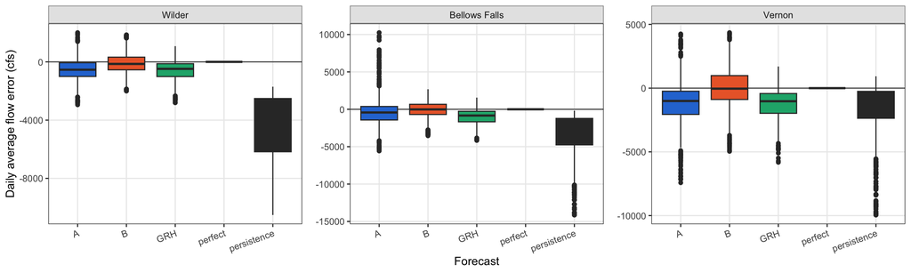

#### Winter

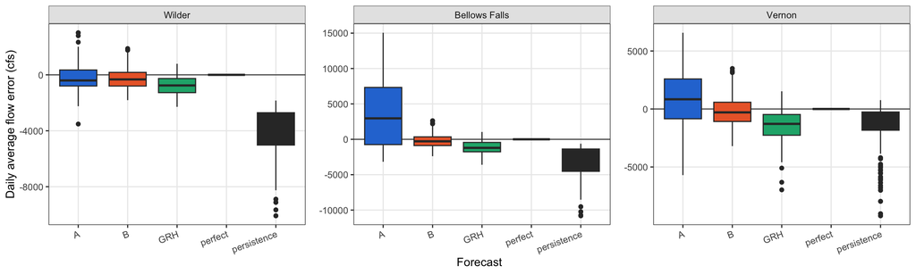

#### Spring

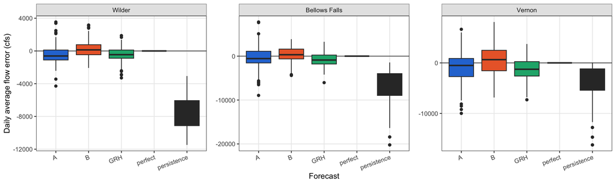

#### Summer

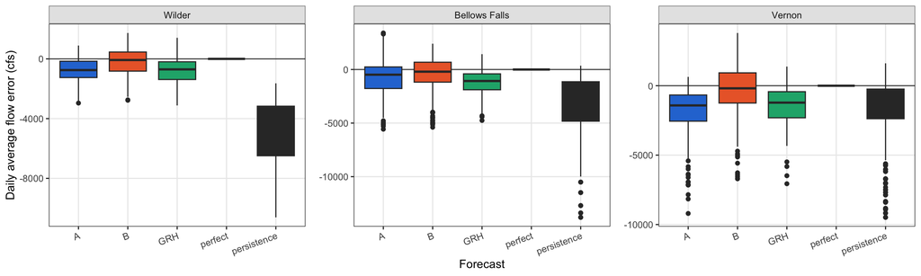

#### Fall

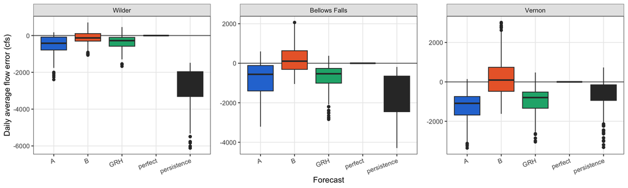

### Day Ahead Observed vs. Forecast Scatterplot

#### Overall

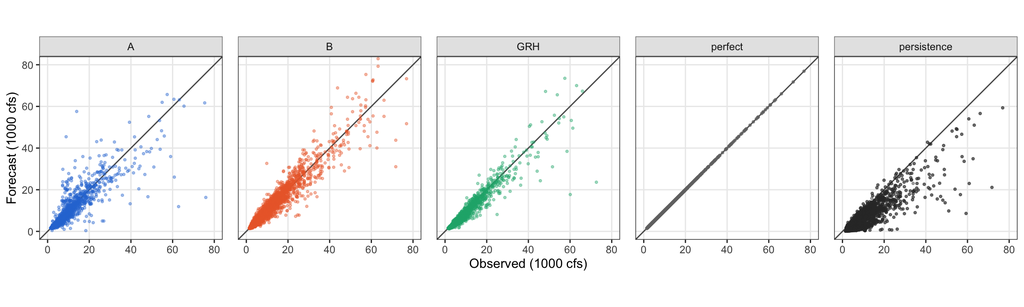

#### Winter

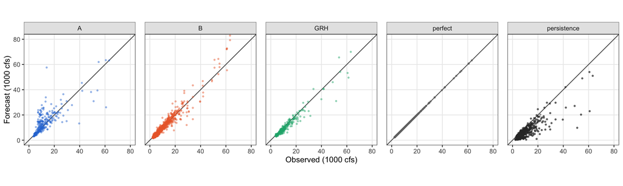

#### Spring

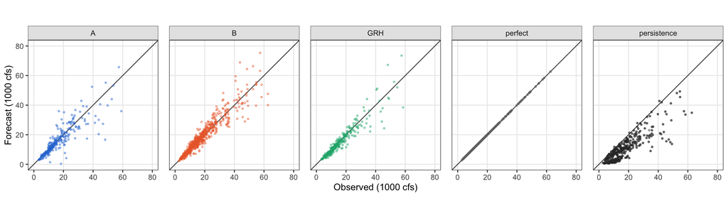

#### Summer

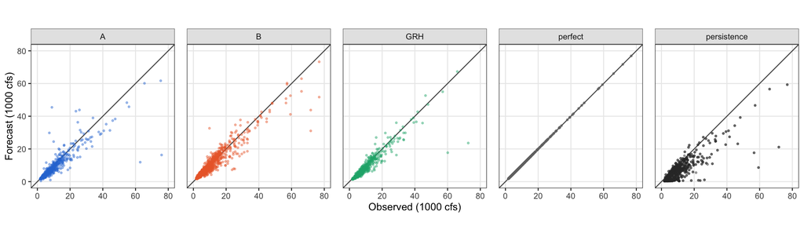

#### Fall

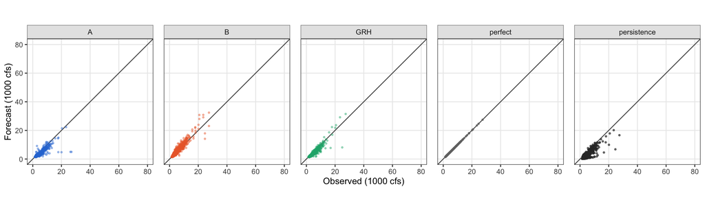

### Day Ahead Performance by Month

Paper Figure 4 is this plot for the four metrics below.

#### Kling-Gupta Efficiency (KGE)

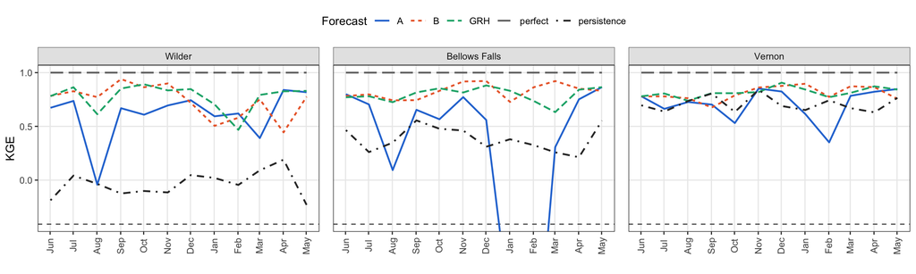

#### Nash-Suttecliffe Efficiency (NSE)

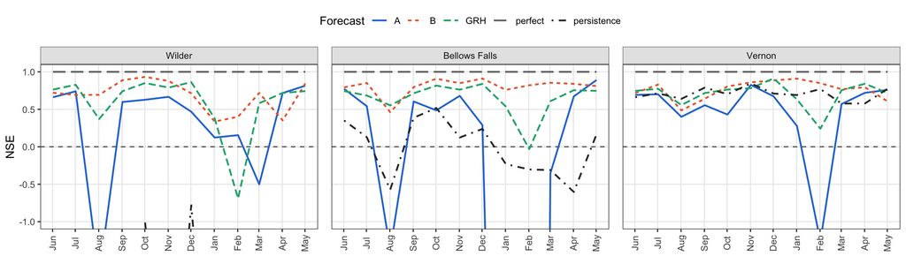

#### Pearson’s Correlation (r)

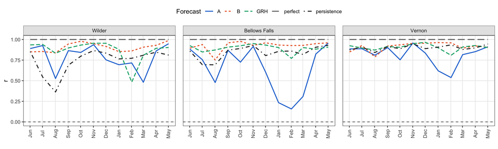

#### Percent Bias

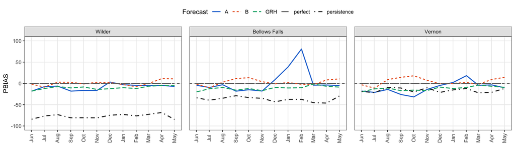

## Daily forecast performance vs lead time

Paper Figure 3 is the “Overall” tab of each metric below.

### Kling-Gupta Efficiency (KGE)

#### Overall

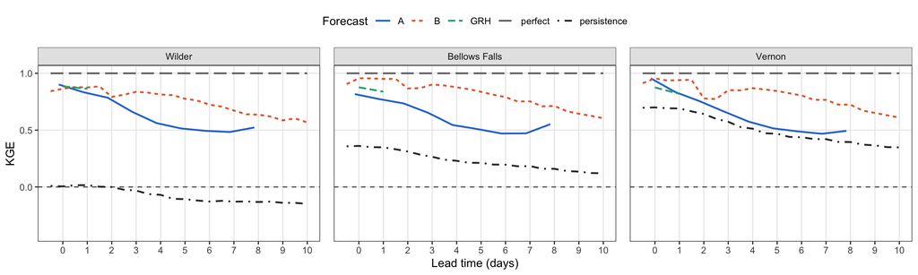

#### Winter

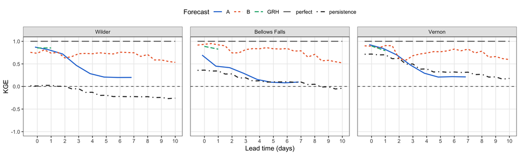

#### Spring

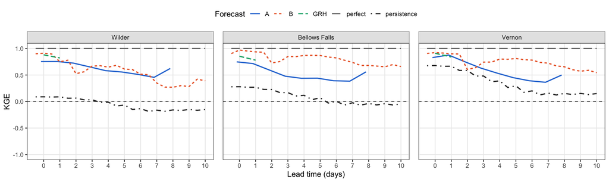

#### Summer

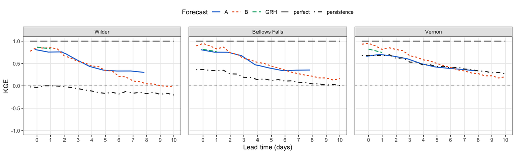

#### Fall

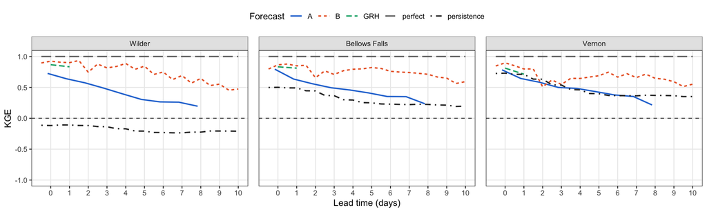

### Nash-Suttecliffe Efficiency (NSE)

#### Overall

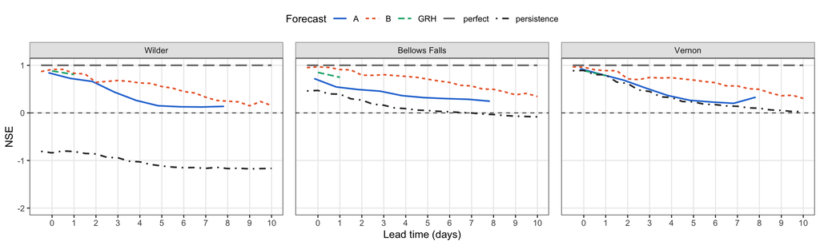

#### Winter

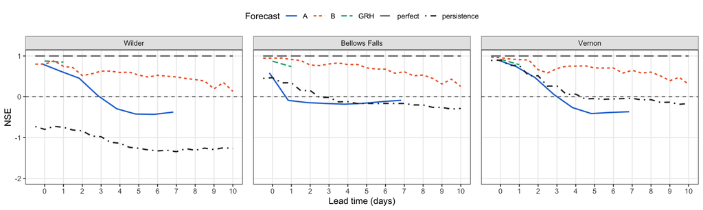

#### Spring

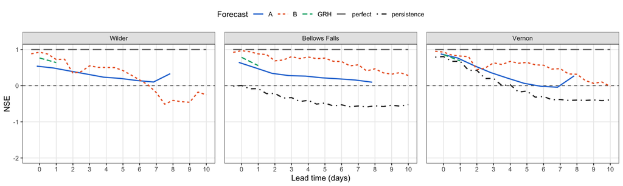

#### Summer

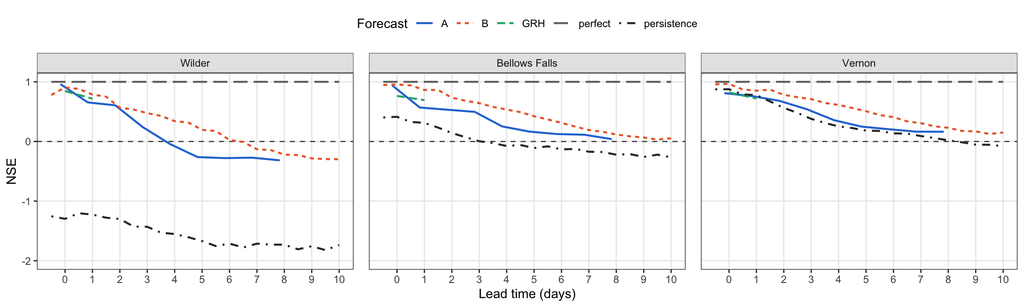

#### Fall

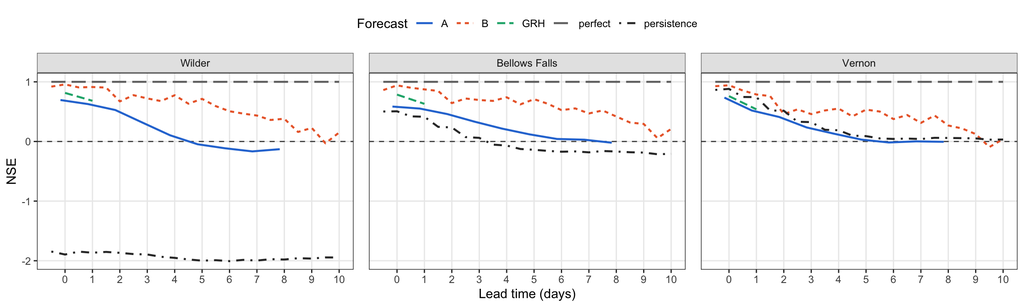

### Pearson’s Correlation (r)

#### Overall

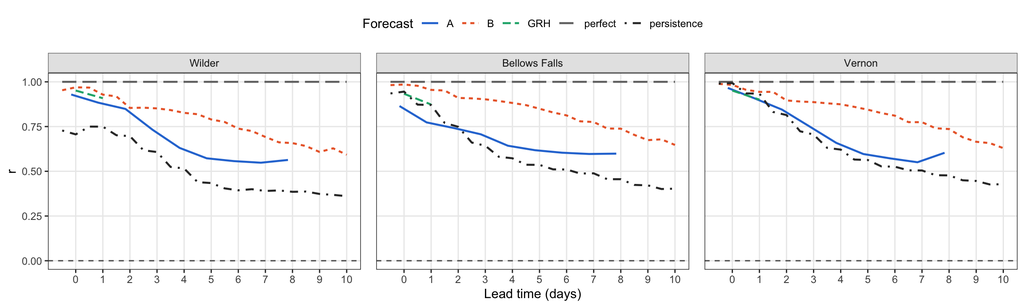

#### Winter

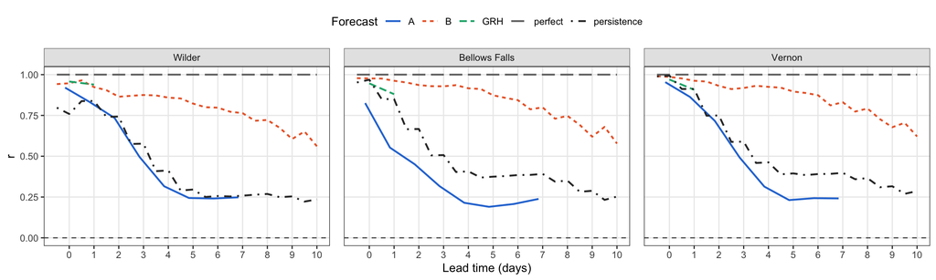

#### Spring

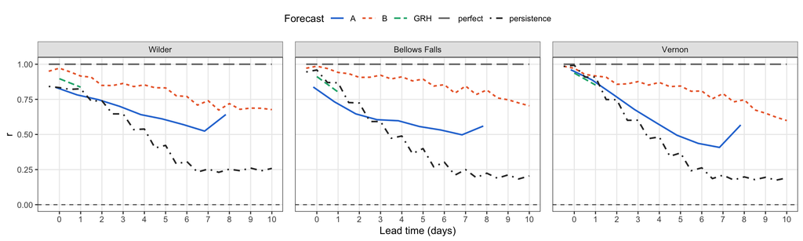

#### Summer

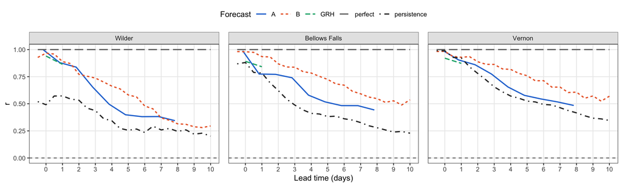

#### Fall

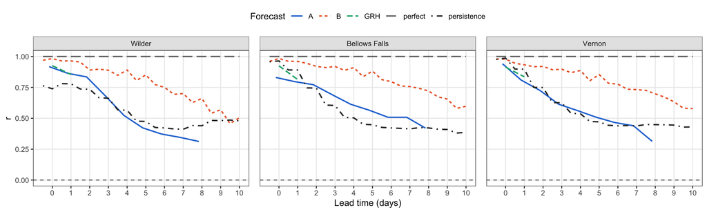